# Data Visualization

## Keys for specifications

`shape`

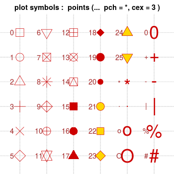

[source](http://www.cookbook-r.com/Graphs/Shapes_and_line_types/figure/unnamed-chunk-2-1.png)

## shape key

- *geoms* that draw have points have a `shape` parameter
- these include numeric values (don’t need quotes for these) and some characters values (need quotes for these)

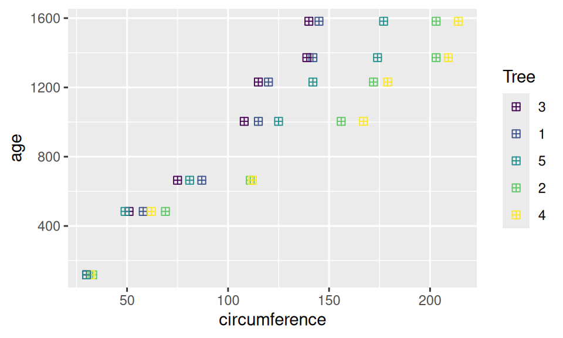

```r
Orange %>% ggplot(aes(x = circumference,
                      y = age,
                      color = Tree)) +
  geom_point(size = 2, shape = 12)
```

## Can make your own theme to use on plots!

Guide on how to: https://rpubs.com/mclaire19/ggplot2-custom-themes

## Group and/or color by variable’s values

First, we will read in some data for the purpose of demonstration about food prices over time.

```r
food <- read_csv(
  file = "http://jhudatascience.org/intro_to_r/data/food_price.csv")
```

## Food data

- 2 different categories (e.g. pasta, rice)
- 4 different items (e.g. 2 of each category)
- 10 price values changes collected over time for each item

```r
food
```

```
# A tibble: 40 × 4
   item_ID item_categ observation_time item_price_change
   <chr>   <chr>                 <dbl>             <dbl>
 1 ID_1    pasta                     1               1.5
 2 ID_1    pasta                     2               1.5
 3 ID_1    pasta                     3               0.5
 4 ID_1    pasta                     4               2.5
 5 ID_1    pasta                     5               0.5
 6 ID_1    pasta                     6               0.5
 7 ID_1    pasta                     7               1.5
 8 ID_1    pasta                     8               1.5
 9 ID_1    pasta                     9               2.5
10 ID_1    pasta                    10               1.5
# ℹ 30 more rows
```

## Starting a plot

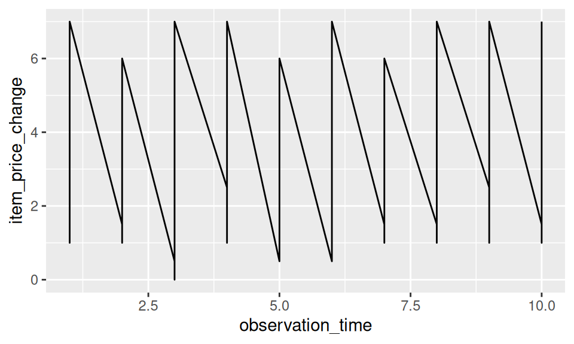

```r
ggplot(food, aes(x = observation_time,
                 y = item_price_change)) +
  geom_line()
```

## If it looks confusing to you, try again

[figure not shown]

## Using `group` in plots

You can use `group` element in a mapping to indicate that each `item_ID` will have a separate price line.

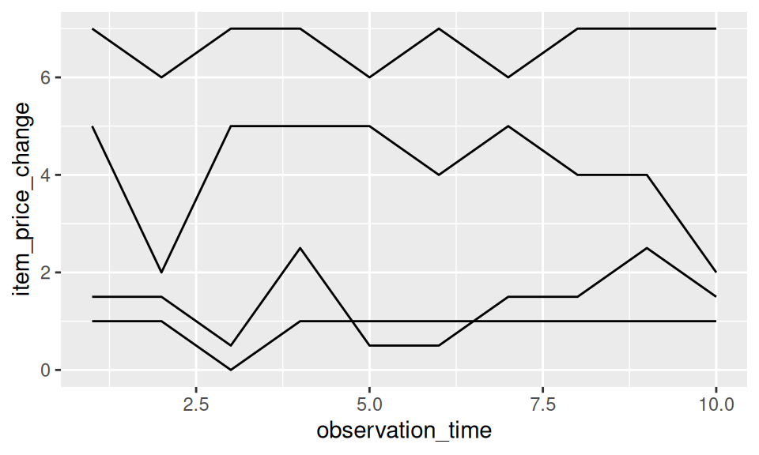

```r
ggplot(food, aes(x = observation_time,
                           y = item_price_change,
                           group = item_ID)) +
  geom_line()
```

## Adding color will automatically group the data

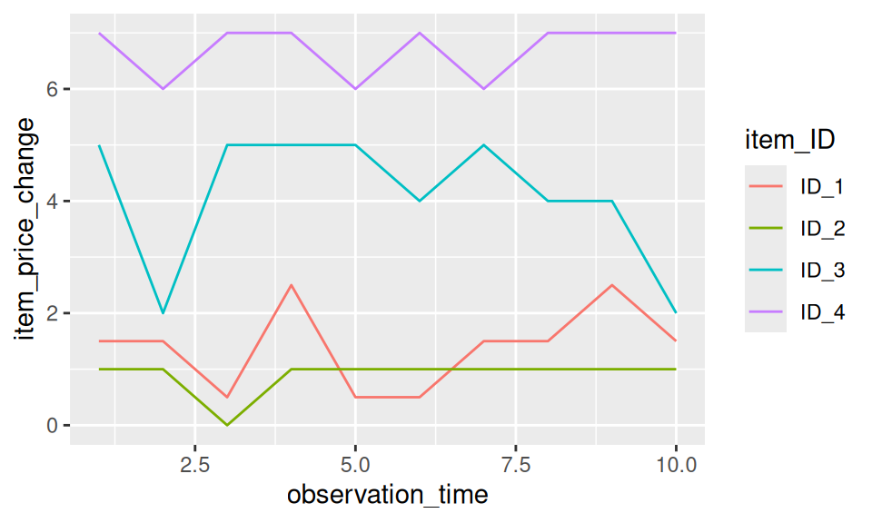

```r
ggplot(food, aes(x = observation_time,
                           y = item_price_change,
                       color = item_ID)) +
  geom_line()
```

## Adding color will automatically group the data

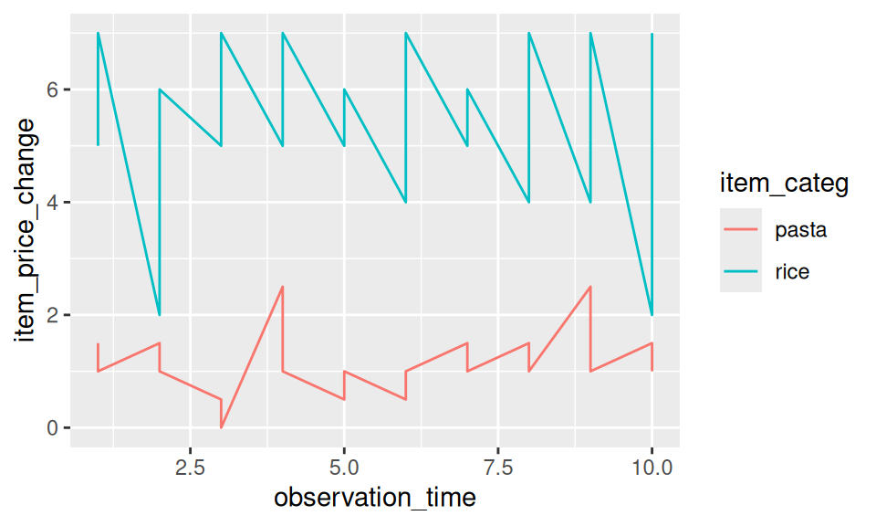

```r
ggplot(food, aes(x = observation_time,
                 y = item_price_change,
                 color = item_categ)) +
  geom_line()
```

## Sometimes you need group and color

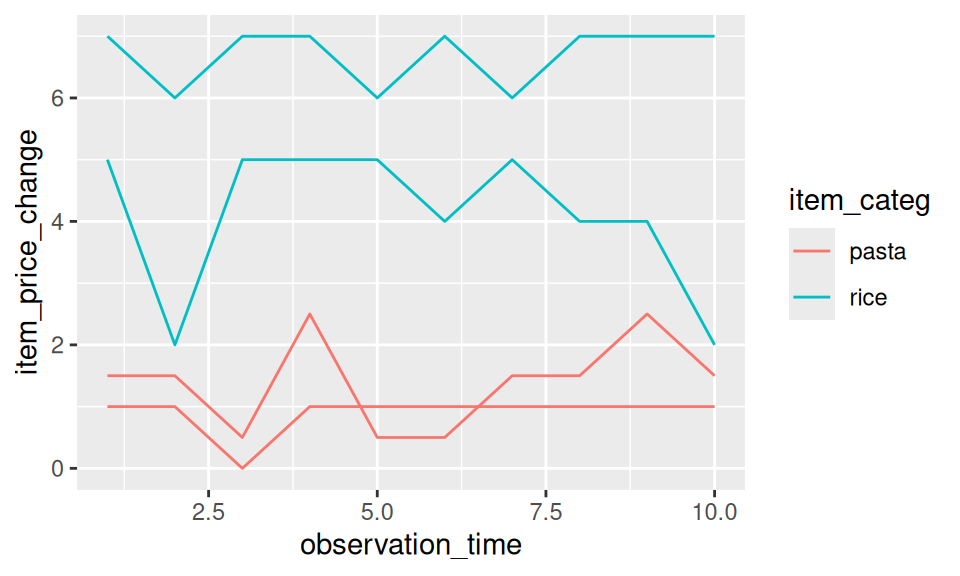

```r
ggplot(food, aes(x = observation_time,
                 y = item_price_change,
                 group = item_ID,
                 color = item_categ)) +
  geom_line()
```

## Adding a facet can help make it easier to see what is happening

Two options: `facet_grid()`- creates a grid shape `facet_wrap()` -more flexible

Need to specify how you are faceting with the `~` sign.

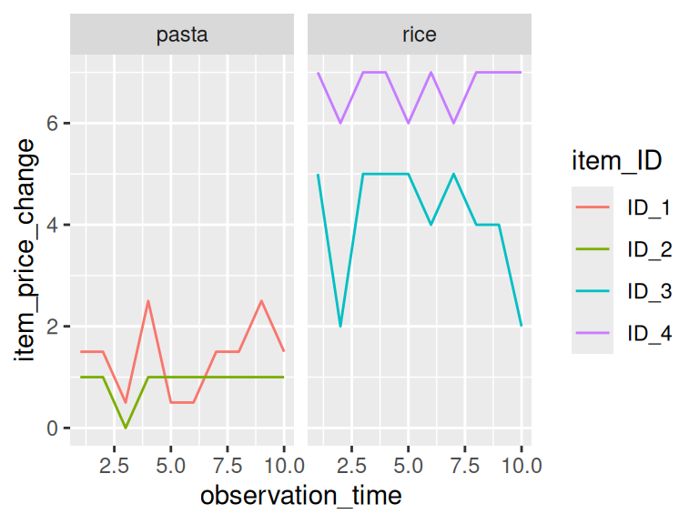

```r
ggplot(food, aes(x = observation_time,
                 y = item_price_change,
                 color = item_ID)) +
  geom_line() +
  facet_grid( ~ item_categ)
```

## facet_wrap()

- more flexible - arguments `ncol` and `nrow` can specify layout
- can have different scales for axes using `scales = "free_x"`, `scales = "free_y"`, or `scales = "free"`

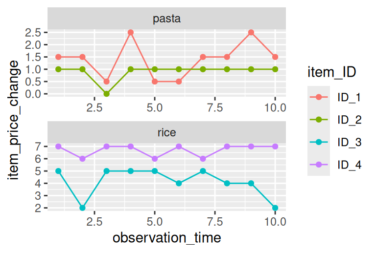

```r
rp_fac_plot <- ggplot(food, aes(x = observation_time, y = item_price_change,color = item_ID)) +
                  geom_line()  +
                  geom_point() +
                  facet_wrap( ~ item_categ, ncol = 1, scales = "free")
rp_fac_plot
```

## Tips!

Let’s talk additional tricks and tips for making ggplots!

## Tips - Color vs Fill

- `color` is needed for points and lines
- `fill` is generally needed for boxes and bars

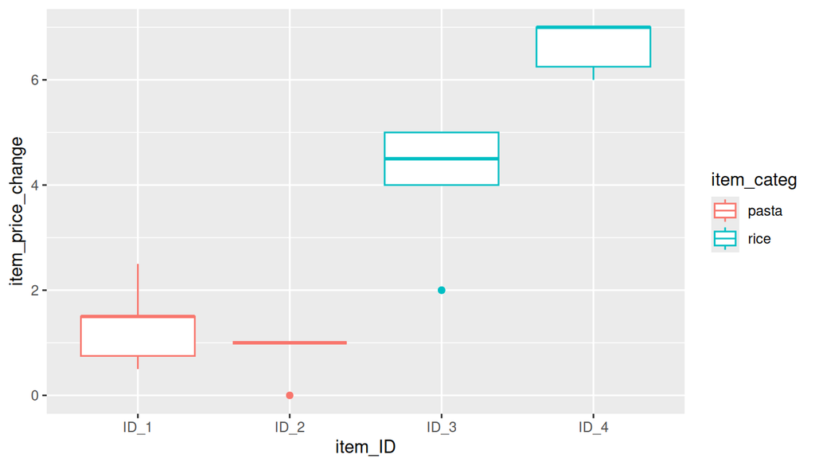

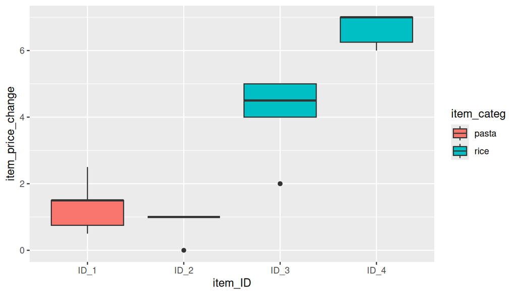

```r
ggplot(food, aes(x = item_ID,
                 y = item_price_change,
                 color = item_categ)) + #color creates an outline
  geom_boxplot()

ggplot(food, aes(x = item_ID,
                 y = item_price_change,
                 fill = item_categ)) + # fills the boxplot
  geom_boxplot()
```

## Tip - Good idea to add jitter layer to top of box plots

Can add `width` argument to make the jitter more narrow.

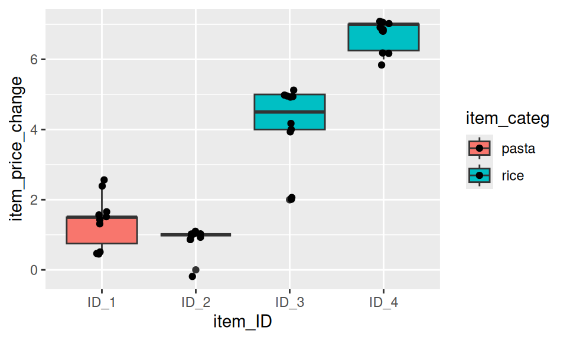

```r
ggplot(food, aes(x = item_ID,
                 y = item_price_change,
                 fill = item_categ)) +
  geom_boxplot() +
  geom_jitter(width = .06)
```

## Tip - be careful about colors for color vision deficiency

`scale_fill_viridis_d()` for discrete /categorical data `scale_fill_viridis_c()` for continuous data

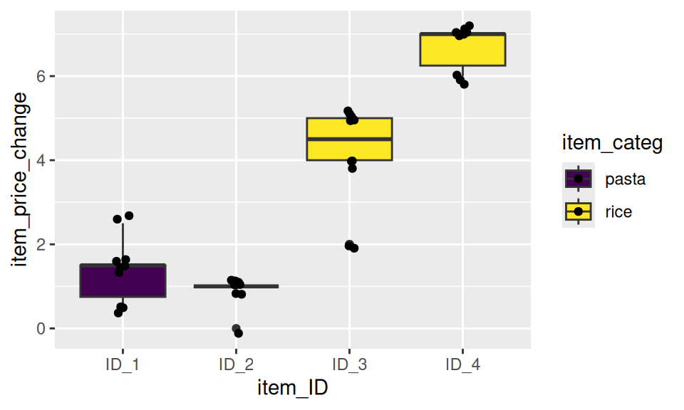

```r
ggplot(food, aes(x = item_ID,
                 y = item_price_change,
                 fill = item_categ)) +
  geom_boxplot() +
  geom_jitter(width = .06) +
  scale_fill_viridis_d()
```

## Tip - can pipe data after wrangling into ggplot()

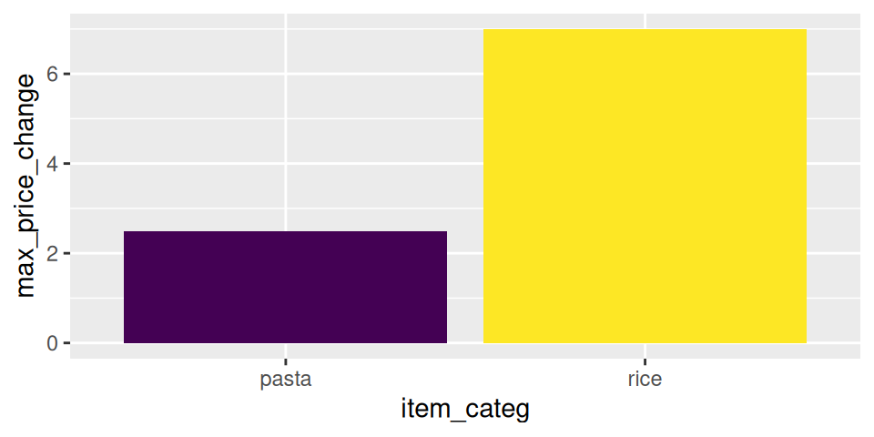

```r
food_bar <-food %>%
  group_by(item_categ) %>%
  summarize("max_price_change" = max(item_price_change)) %>%

ggplot(aes(x = item_categ,
           y = max_price_change,
           fill = item_categ)) +
  scale_fill_viridis_d()+
  geom_col() +
  theme(legend.position = "none")

food_bar
```

## Tip - color outside of `aes()`

Can be used to add an outline around column/bar plots.

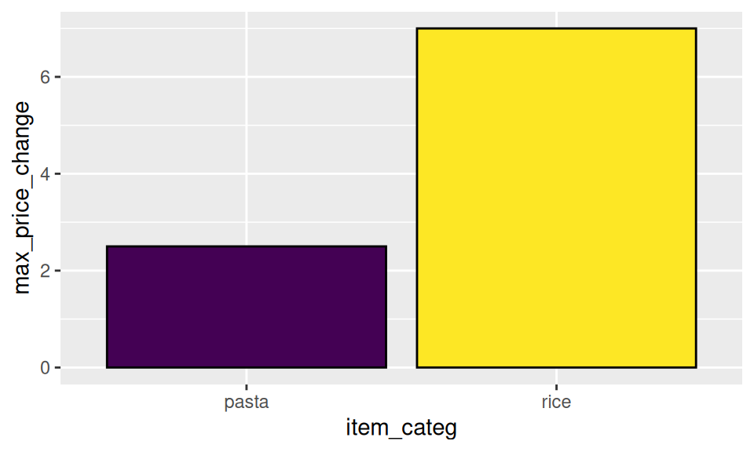

```r
food_bar +
   geom_col(color = "black")
```

## Tip - col vs bar

`geom_bar(x =)` can only use one `aes` mapping `geom_col(x = , y = )` can have two

## Tip - Check what you plot

⚠ May not be plotting what you think you are! ⚠

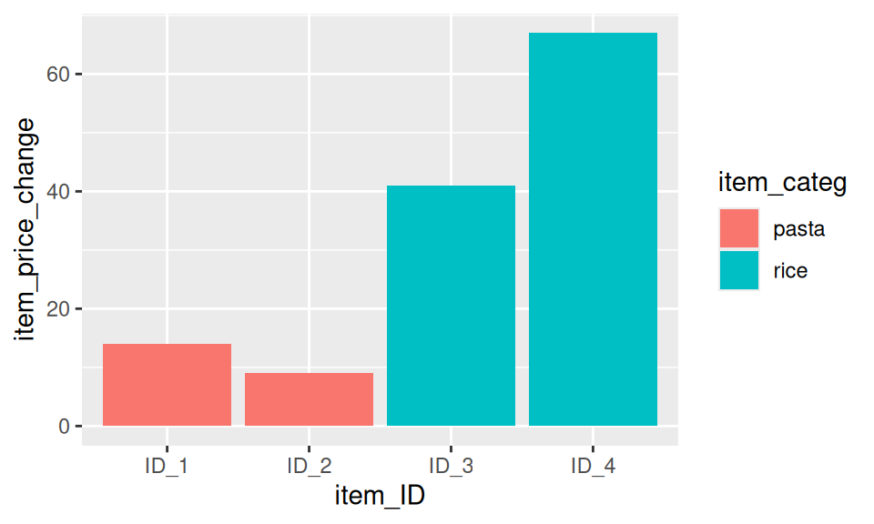

```r
ggplot(food, aes(x = item_ID,
                 y = item_price_change,
                 fill = item_categ)) +
  geom_col()
```

## What did we plot? Always good to check it is correct!

```r
head(food, n = 3)
```

```
# A tibble: 3 × 4
  item_ID item_categ observation_time item_price_change
  <chr>   <chr>                 <dbl>             <dbl>
1 ID_1    pasta                     1               1.5
2 ID_1    pasta                     2               1.5
3 ID_1    pasta                     3               0.5
```

```r
food %>% group_by(item_ID) %>%
  summarize(sum = sum(item_price_change))
```

```
# A tibble: 4 × 2
  item_ID   sum
  <chr>   <dbl>
1 ID_1       14
2 ID_2        9
3 ID_3       41
4 ID_4       67
```

## Try that again

```r
food %>% group_by(item_categ, item_ID) %>%
  summarize(mean_change = mean(item_price_change))
```

```
# A tibble: 4 × 3
# Groups:   item_categ [2]
  item_categ item_ID mean_change
  <chr>      <chr>         <dbl>
1 pasta      ID_1            1.4
2 pasta      ID_2            0.9
3 rice       ID_3            4.1
4 rice       ID_4            6.7
```

## Try that again

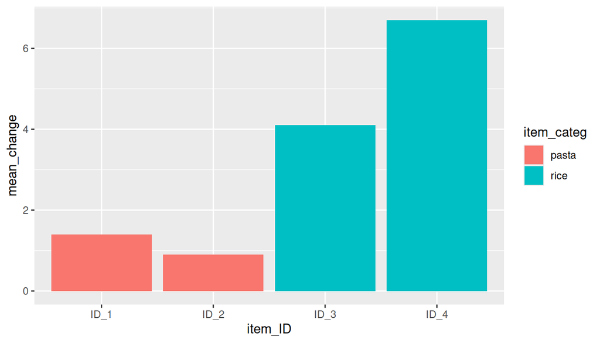

```r
food %>% group_by(item_categ, item_ID) %>%
  summarize(mean_change = mean(item_price_change)) %>%

ggplot(aes(x = item_ID,
           y = mean_change,
           fill = item_categ)) +
  geom_col()
```

## Tip - make sure labels aren’t too small

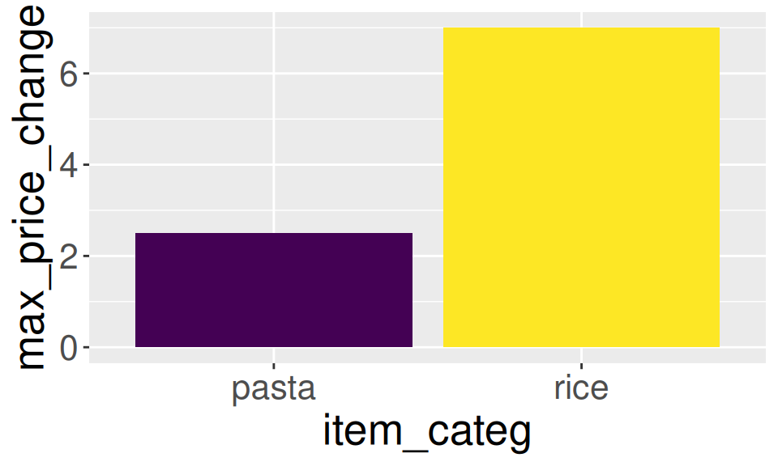

```r
food_bar +
  theme(text = element_text(size = 20))
```

## Tip- if you need you can remove outliers

Set `outlier.shape = NA` to get ride of outliers. Be careful about if you really should remove these!

However, if can be helpful if your plot is getting stretched to accommodate plotting an outlier. You can always say in the figure legend what you removed.

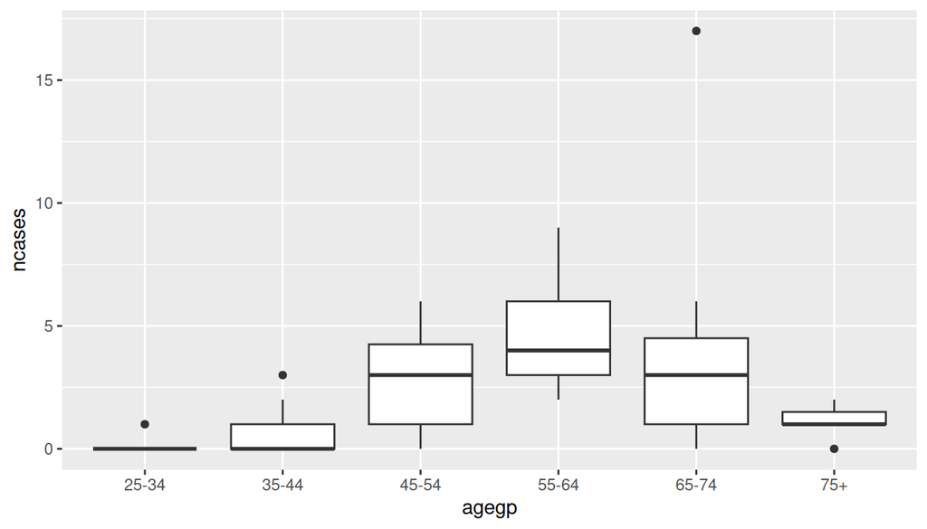

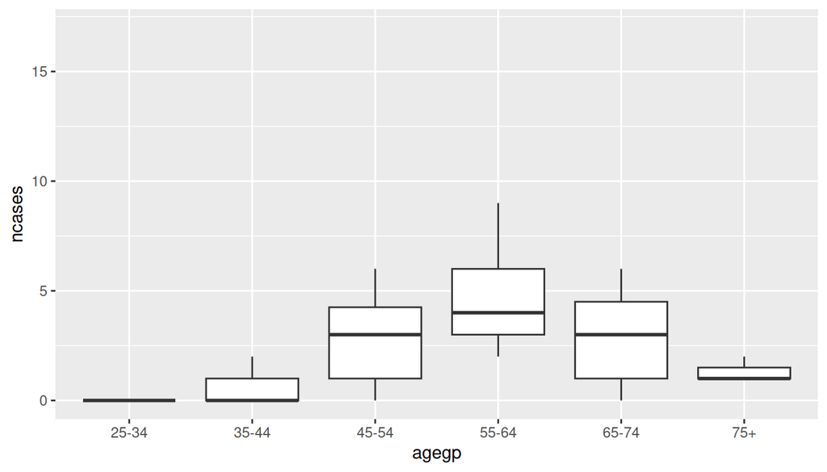

```r
esoph1 <- ggplot(esoph, aes(y = ncases, x = agegp)) +
  geom_boxplot()

esoph2 <- ggplot(esoph, aes(y = ncases, x = agegp)) +
  geom_boxplot(outlier.shape = NA)
```

## NA Values

- if it is a numeric value it will just get dropped from the graph and you will see a warning
- it is categorical you will see it on the graph and will need to filter to remove the NA category

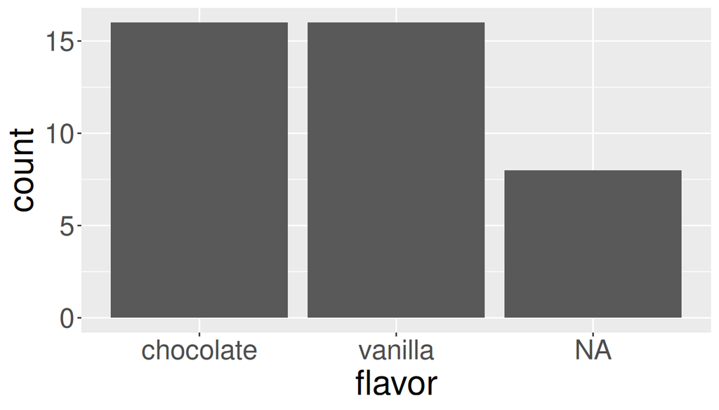

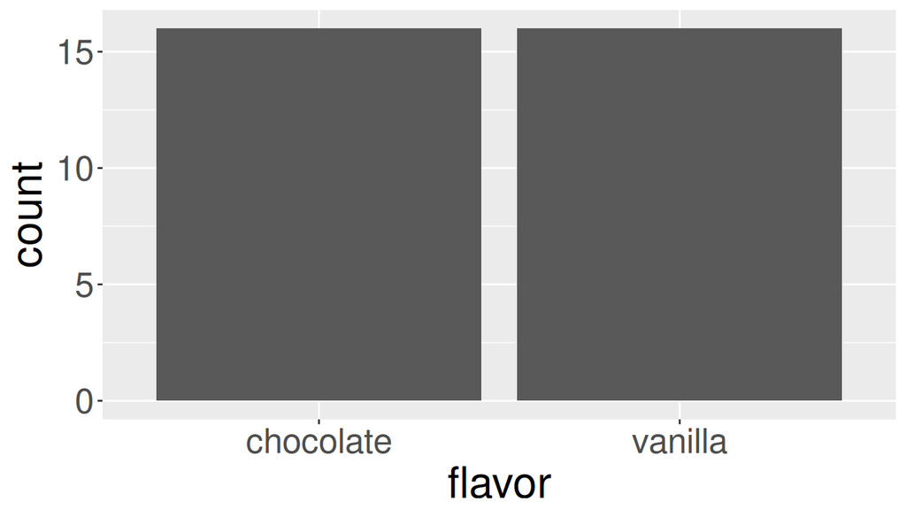

```r
icecream <-tibble(flavor =
            rep(c("chocolate", "vanilla", NA,"chocolate", "vanilla"), 8))

icecream1 <- ggplot(icecream, aes(x = flavor)) + geom_bar() +
              theme(text=element_text(size=24))

icecream2 <- icecream %>% drop_na(flavor)  %>%
                ggplot( aes(x = flavor)) + geom_bar() +
                  theme(text=element_text(size=24))
```

## Extensions

## `patchwork` package

Great for combining plots together

Also check out the [`patchwork` package](https://patchwork.data-imaginist.com/)

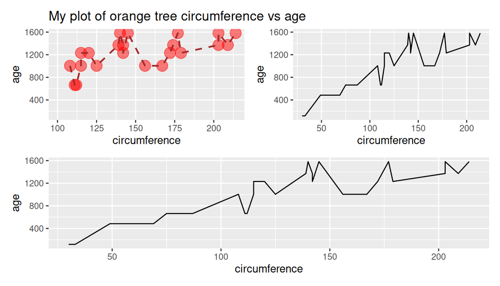

```r
#install.packages("patchwork")
library(patchwork)
(plt1 + plt2)/plt2
```

## `directlabels` package

Great for adding labels directly onto plots https://www.opencasestudies.org/ocs-bp-co2-emissions/

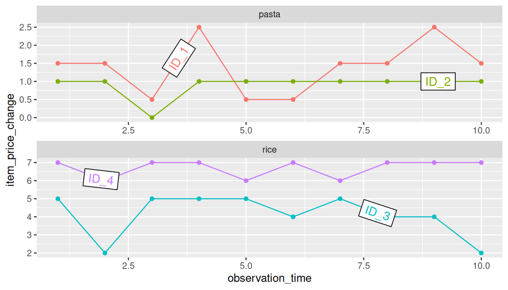

```r
#install.packages("directlabels")
library(directlabels)
direct.label(rp_fac_plot, method = list("angled.boxes"))
```

## plotly

```r
#install.packages("plotly")
library("plotly") # creates interactive plots!
ggplotly(rp_fac_plot)
```

[interactive chart not shown]

Also check out the [`ggiraph` package](https://www.rdocumentation.org/packages/ggiraph/versions/0.6.1)

## Saving plots

## Saving a ggplot to file

A few options:

- RStudio > Plots > Export > Save as image / Save as PDF
- RStudio > Plots > Zoom > [right mouse click on the plot] > Save image as
- In the code

```r
ggsave(filename = "saved_plot.png",  # will save in working directory
       plot = rp_fac_plot,
       width = 6, height = 3.5)               # by default in inches
```

## GUT CHECK: How to we make sure that the boxplots are filled with color instead of just the outside boarder?

A. Use the `fill` argument in the `aes` specification

B. Use `color` argument in `geom_boxplot()`

## GUT CHECK: If our plot is too complicated to read, what might be a good option to fix this?

A. add more `theme()` layers

B. Use `facet_grid()` to split the plot up

## Summary

- The `theme()` function helps you specify aspects about your plot
  - move or remove a legend with `theme(legend.position = "none")`
  - change font aspects of individual text elements `theme(plot.title = element_text(size = 20))`
  - center a title: `theme(plot.title = element_text(hjust = 0.5))`
- sometimes you need to add a `group` element to `aes()` if your plot looks strange
- make sure you are plotting what you think you are by checking the numbers!
- `facet_grid(~ variable)` and `facet_wrap(~variable)` can be helpful to quickly split up your plot
  - `facet_wrap()` allows for a `scales = "free"` argument so that you can have a different axis scale for different plots
- use `fill` to fill in boxplots

## Good practices for plots

Check out this [guide](https://jhudatascience.org/tidyversecourse/dataviz.html#making-good-plots) for more information!

## Lab 2

🏠 [Class Website](https://jhudatascience.org/intro_to_r/)

💻 [Lab](https://jhudatascience.org/intro_to_r/modules//Data_Visualization/lab/Data_Visualization_Lab.Rmd)

📃 [Day 7 Cheatsheet](https://jhudatascience.org/intro_to_r//modules/cheatsheets/Day-7.pdf)

📃 [Posit’s theme cheatsheet](https://github.com/claragranell/ggplot2/blob/main/ggplot_theme_system_cheatsheet.pdf)

📃 [Posit’s `ggplot2` Cheatsheet](https://rstudio.github.io/cheatsheets/data-visualization.pdf)

Image by [Gerd Altmann](https://pixabay.com/users/geralt-9301/?utm_source=link-attribution&utm_medium=referral&utm_campaign=image&utm_content=812226) from [Pixabay](https://pixabay.com//?utm_source=link-attribution&utm_medium=referral&utm_campaign=image&utm_content=812226)

## Extra Slides

## Customize the look of the plot

You can change the look of whole plot - **specific elements, too** - like changing and font size - or even more [fonts](https://blog.revolutionanalytics.com/2012/09/how-to-use-your-favorite-fonts-in-r-charts.html)

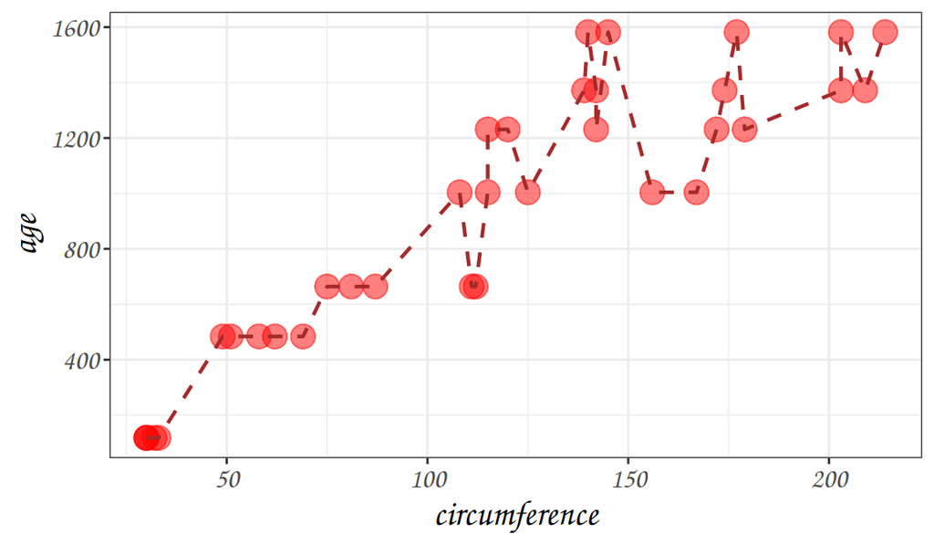

```r
ggplot(Orange, aes(x = circumference, y = age)) +
  geom_point(size = 5, color = "red", alpha = 0.5) +
  geom_line(size = 0.8, color = "brown", linetype = 2) +
  theme_bw() +
  theme(text=element_text(size=16,  family="Comic Sans MS"))
```